# 1000plus collateral flow & perfusion project

Ahmed Khalil, MD PhD

26 September, 2019

### Methods

**Reperfusion** is defined as the relative Tmax >6s change (% of baseline).  
Surrogates for good collateral flow in this study are:  
* Degree of reperfusion in non-recanalizers  
* The hypoperfusion intensity ration (HIR) at baseline (lower is better), defined according to:  
*Bang, O. Y. et al. (2008) ‘Determinants of the distribution and severity of hypoperfusion in patients with ischemic stroke.’, Neurology*  
* The modified ASITN/SIR Collateral Flow Grading System (adapted for DSC-MRI, aka “Higashida score”), according to:  
*Campbell BC V, Christensen S, Tress BM, Churilov L, Desmond PM, Parsons MW, Alan Barber P, Levi CR, Bladin C, Donnan GA, Davis SM (2013) Failure of collateral blood flow is associated with infarct growth in ischemic stroke. J Cereb Blood Flow Metab* and dichotomized into good (3-4) and poor (0-2) according to: *Galinovic I, Kochova E, Khalil A, Villringer K, Piper SK, Fiebach JB (2018) The ratio between cerebral blood flow and Tmax predicts the quality of collaterals in acute ischemic stroke. PLoS One 13:e0190811*

The outcome measures in this study are:  
* Extent of reperfusion - relative Tmax >6s change (%)  
* Modified Rankin Scale at Day 90  
* Absolute infarct growth on DWI between days 1 and 2 (mL)  
* Absolute infarct growth between days 1 (DWI) and 5 (FLAIR) (mL)

All regression analyses are performed using a robust GLM (“High Breakdown And High Efficiency Robust Linear Regression”) using the R function “lmrob” from the “robustbase” package.  
Citation of package:  
*Martin Maechler, Peter Rousseeuw, Christophe Croux, Valentin Todorov, Andreas Ruckstuhl, Matias Salibian-Barrera, Tobias Verbeke, Manuel Koller, Eduardo L. T. Conceicao and Maria Anna di Palma (2018). robustbase: Basic Robust Statistics R package version 0.93-0. URL http://CRAN.R-project.org/package=robustbase*  
Citation of robust GLM:  
*Yohai, V. J. (1987). High breakdown-point and high efficiency robust estimates for regression. The Annals of Statistics, 642-656.*

For visualization (not analysis) purposes, outliers are **not** shown on the boxplots.

**Power analysis:**

Sample size needed to detect a minimum effect size (R2/1-R2) of 0.1 at significance level of 0.05 and power of 0.8 with 8 predictors (including interactions) = 158. Performed with the R package “pwr”.  
Citation of package:  
*Stephane Champely (2018). pwr: Basic Functions for Power Analysis. R package version 1.2-2. https://CRAN.R-project.org/package=pwr*

### Descriptive statistics

| Statistic | N | Mean | St. Dev. | Min | Pctl(25) | Median | Pctl(75) | Max |
| --- | --- | --- | --- | --- | --- | --- | --- | --- |
| Age | 184 | 71.6 | 13.3 | 23 | 65.8 | 74 | 82 | 93 |
| Time onset-to-imaging | 184 | 6.9 | 6.7 | 0.0 | 1.5 | 3.4 | 12.0 | 24.0 |
| NIHSS admission | 184 | 8.2 | 6.3 | 0 | 3 | 6 | 13 | 25 |
| NIHSS discharge | 183 | 4.3 | 5.7 | 0.0 | 0.0 | 2.0 | 6.0 | 29.0 |
| mRS day 90 | 148 | 2.3 | 1.9 | 0.0 | 1.0 | 2.0 | 4.0 | 6.0 |
| DWI volume day 1 | 184 | 15.3 | 27.6 | 0.0 | 1.0 | 5.4 | 17.8 | 231.4 |
| DWI volume day 2 | 184 | 31.2 | 49.5 | 0.0 | 3.0 | 12.4 | 39.1 | 324.0 |
| FLAIR volume day 5 | 140 | 41.4 | 57.4 | 0.01 | 5.9 | 17.9 | 54.8 | 300.4 |
| HIR day 1 | 184 | 0.3 | 0.2 | 0.0 | 0.1 | 0.2 | 0.4 | 1.0 |
| HIR day 2 | 176 | 0.2 | 0.2 | 0.0 | 0.01 | 0.1 | 0.3 | 1.0 |
| Tmax >6s volume day 1 | 184 | 45.9 | 49.9 | 0 | 11 | 27 | 67.2 | 259 |
| Tmax >6s volume day 2 | 184 | 27.0 | 85.9 | 0 | 1 | 7 | 27.6 | 1,094 |

```
##               Level     N    %
## 1  hig.d1         0     4  2.2
## 2                 1    31 16.8
## 3                 2    49 26.6
## 4                 3    49 26.6
## 5                 4    50 27.2
## 6               NaN     0  0.0
## 7         <Missing>     1  0.5
## 8  hig.d2         0     3  1.6
## 9                 1    22 12.0
## 10                2    38 20.7
## 11                3    38 20.7
## 12                4    80 43.5
## 13              NaN     0  0.0
## 14        <Missing>     3  1.6
## 15   TIMI         0    71 38.6
## 16                1    15  8.2
## 17                2    43 23.4
## 18                3    55 29.9
## 19   circ  Anterior   141 76.6
## 20        Posterior    43 23.4
## 21    Sex    Female    78 42.4
## 22             Male   106 57.6
## 23 iv.tPA        No   104 56.5
## 24              Yes    80 43.5
```

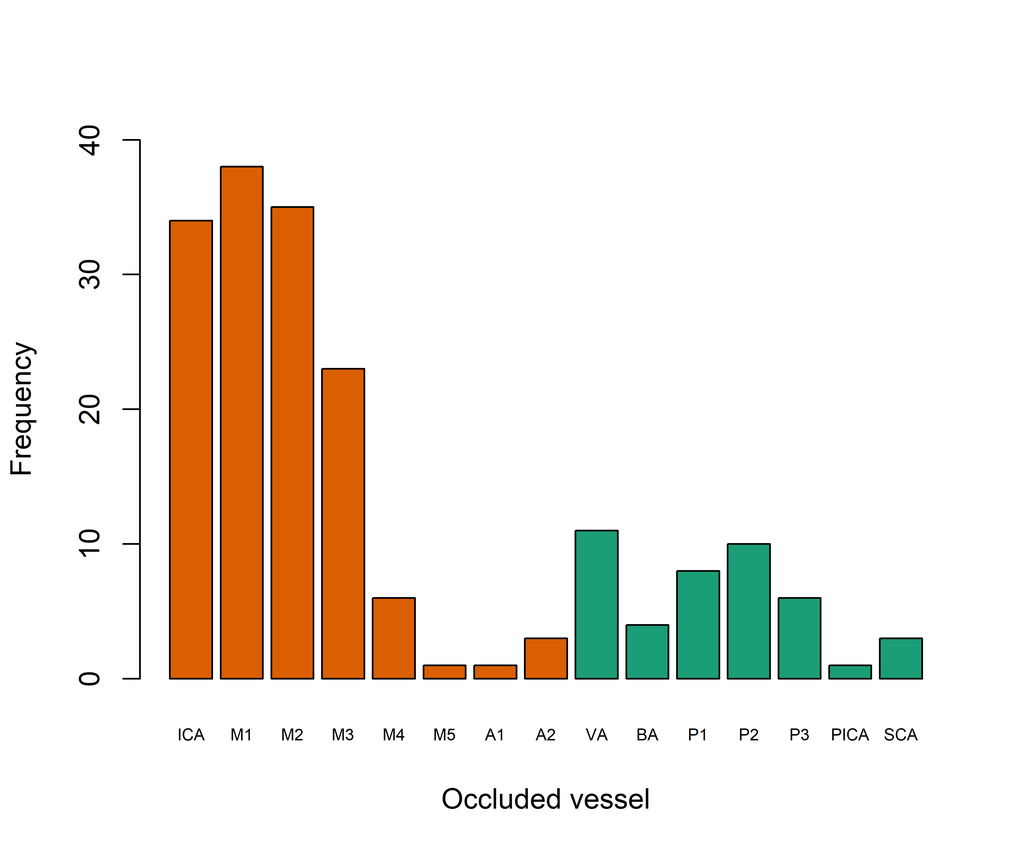

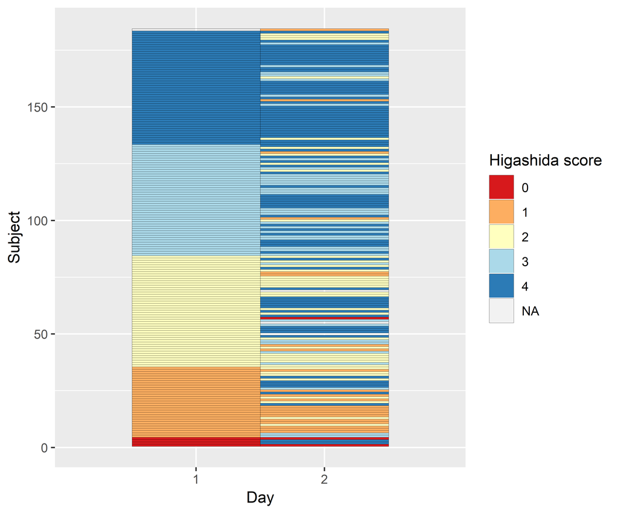

*Plot showing the change in Higashida scores over time for each patient.*

### Predictors of extent of reperfusion

```
## NOTE: Rekan:HIR1 does not appear in the model
```

png 2 png 2

**Predictors of extent of reperfusion**

|  | HIR | Higashida |
| --- | --- | --- |
| NIHSS on admission | -0.011 (0.024) | 0.005 (0.021) |
|  | t = -0.440 | t = 0.213 |
|  | p = 0.661 | p = 0.832 |
| IV thrombolysis | 0.059 (0.043) | 0.069* (0.041) |
|  | t = 1.372 | t = 1.687 |
|  | p = 0.172 | p = 0.094 |
| Recanalization | 0.242*** (0.042) | 0.188*** (0.052) |
|  | t = 5.774 | t = 3.614 |
|  | p = 0.00000 | p = 0.0004 |
| HIR | -0.033 (0.032) |  |
|  | t = -1.008 |  |
|  | p = 0.315 |  |
| Higashida (poor) |  | -0.190*** (0.058) |
|  |  | t = -3.294 |
|  |  | p = 0.002 |
| Circulation (posterior) | -0.071 (0.052) | -0.054 (0.048) |
|  | t = -1.367 | t = -1.111 |
|  | p = 0.174 | p = 0.268 |
| Recanalization*HIR | 0.041 (0.042) |  |
|  | t = 0.970 |  |
|  | p = 0.334 |  |
| Recanalization*Higashida (poor) |  | 0.099 (0.077) |
|  |  | t = 1.288 |
|  |  | p = 0.200 |
| Constant | 0.047 (0.037) | 0.137*** (0.044) |
|  | t = 1.248 | t = 3.090 |
|  | p = 0.214 | p = 0.003 |
| Observations | 178 | 178 |
| R<sup>2</sup> | 0.226 | 0.283 |
| Adjusted R<sup>2</sup> | 0.199 | 0.257 |
| Residual Std. Error (df = 171) | 0.260 | 0.246 |
| *Note:* | p<0.1; p<0.05; p<0.01 |  |

```
## Model 1: bars denote 0.5 (inner) resp. 0.95 (outer) confidence intervals (computed from standard errors).
```

```
## Model 2: bars denote 0.5 (inner) resp. 0.95 (outer) confidence intervals (computed from standard errors).
```

png 2

### Predictors of clinical outcome

```
## NOTE: Rekan:HIR1 does not appear in the model
```

png 2 png 2

```
## NOTE: Rekan:Tmax_6_reperf_rel does not appear in the model
```

png 2

**Predictors of long-term clinical outcome (mRS day 90)**

|  | HIR | Higashida | Reperfusion |
| --- | --- | --- | --- |
| NIHSS on admission | 0.511*** (0.084) | 0.531*** (0.081) | 0.557*** (0.080) |
|  | t = 6.116 | t = 6.554 | t = 6.999 |
|  | p = 0.000 | p = 0.000 | p = 0.000 |
| IV tPA (yes) | -0.281* (0.149) | -0.276* (0.151) | -0.312** (0.151) |
|  | t = -1.886 | t = -1.835 | t = -2.062 |
|  | p = 0.062 | p = 0.069 | p = 0.042 |
| Recanalization (yes) | -0.740*** (0.145) | -0.631*** (0.183) | -0.663*** (0.179) |
|  | t = -5.113 | t = -3.449 | t = -3.711 |
|  | p = 0.00001 | p = 0.001 | p = 0.0003 |
| HIR | 0.107 (0.109) |  |  |
|  | t = 0.979 |  |  |
|  | p = 0.330 |  |  |
| Higashida (poor) |  | 0.256 (0.211) |  |
|  |  | t = 1.213 |  |
|  |  | p = 0.228 |  |
| Reperfusion |  |  | -0.017 (0.121) |
|  |  |  | t = -0.138 |
|  |  |  | p = 0.891 |
| Circulation (posterior) | 0.102 (0.163) | 0.112 (0.162) | 0.116 (0.166) |
|  | t = 0.626 | t = 0.690 | t = 0.698 |
|  | p = 0.533 | p = 0.492 | p = 0.487 |
| Recanalization (yes)*HIR | 0.030 (0.144) |  |  |
|  | t = 0.209 |  |  |
|  | p = 0.835 |  |  |
| Recanalization (yes)*Higashida (poor) |  | -0.173 (0.279) |  |
|  |  | t = -0.619 |  |
|  |  | p = 0.538 |  |
| Recanalization (yes)*Reperfusion |  |  | -0.279 (0.390) |
|  |  |  | t = -0.716 |
|  |  |  | p = 0.476 |
| Constant | 0.522*** (0.130) | 0.377** (0.162) | 0.550*** (0.134) |
|  | t = 4.002 | t = 2.329 | t = 4.096 |
|  | p = 0.0002 | p = 0.022 | p = 0.0001 |
| Observations | 148 | 148 | 143 |
| R<sup>2</sup> | 0.396 | 0.390 | 0.388 |
| Adjusted R<sup>2</sup> | 0.371 | 0.364 | 0.361 |
| Residual Std. Error | 0.804 (df = 141) | 0.808 (df = 141) | 0.810 (df = 136) |
| *Note:* | p<0.1; p<0.05; p<0.01 |  |  |

```
## Model 1: bars denote 0.5 (inner) resp. 0.95 (outer) confidence intervals (computed from standard errors).
```

```
## Model 2: bars denote 0.5 (inner) resp. 0.95 (outer) confidence intervals (computed from standard errors).
```

```
## Model 3: bars denote 0.5 (inner) resp. 0.95 (outer) confidence intervals (computed from standard errors).
```

png 2

### Predictors of absolute infarct growth (D1 - D2)

png 2 png 2 png 2

**Predictors of early infarct growth**

|  | HIR | Higashida | Reperfusion |
| --- | --- | --- | --- |
| NIHSS on admission | 0.324*** (0.099) | 0.322*** (0.088) | 0.499*** (0.106) |
|  | t = 3.266 | t = 3.639 | t = 4.722 |
|  | p = 0.002 | p = 0.0004 | p = 0.00001 |
| IV tPA (yes) | -0.374 (1.110) | -0.802 (1.028) | -0.070 (1.230) |
|  | t = -0.337 | t = -0.781 | t = -0.057 |
|  | p = 0.737 | p = 0.436 | p = 0.955 |
| Recanalization (yes) | -0.498 (1.551) | 0.854 (1.226) | 1.488 (1.827) |
|  | t = -0.321 | t = 0.697 | t = 0.815 |
|  | p = 0.749 | p = 0.487 | p = 0.417 |
| HIR | 8.693** (3.890) |  |  |
|  | t = 2.235 |  |  |
|  | p = 0.027 |  |  |
| Higashida (poor) |  | 4.393*** (1.476) |  |
|  |  | t = 2.977 |  |
|  |  | p = 0.004 |  |
| Reperfusion |  |  | -0.004 (0.006) |
|  |  |  | t = -0.608 |
|  |  |  | p = 0.544 |
| Circulation (posterior) | 0.629 (1.220) | 0.512 (1.116) | 0.473 (1.374) |
|  | t = 0.516 | t = 0.459 | t = 0.345 |
|  | p = 0.607 | p = 0.647 | p = 0.731 |
| Recanalization*HIR | 2.859 (4.957) |  |  |
|  | t = 0.577 |  |  |
|  | p = 0.565 |  |  |
| Recanalization*Higashida (poor) |  | -0.154 (1.926) |  |
|  |  | t = -0.080 |  |
|  |  | p = 0.937 |  |
| Recanalization*Reperfusion |  |  | -0.017 (0.020) |
|  |  |  | t = -0.855 |
|  |  |  | p = 0.394 |
| Constant | 1.209 (1.384) | 1.223 (1.120) | 2.433* (1.275) |
|  | t = 0.874 | t = 1.092 | t = 1.909 |
|  | p = 0.384 | p = 0.277 | p = 0.058 |
| Observations | 184 | 184 | 178 |
| R<sup>2</sup> | 0.192 | 0.184 | 0.118 |
| Adjusted R<sup>2</sup> | 0.164 | 0.156 | 0.087 |
| Residual Std. Error | 6.813 (df = 177) | 6.426 (df = 177) | 7.635 (df = 171) |
| *Note:* | p<0.1; p<0.05; p<0.01 |  |  |

### Predictors of absolute infarct growth (D1 - D5)

```
## NOTE: Rekan:HIR1 does not appear in the model
```

png 2 png 2

```
## NOTE: Rekan:Tmax_6_reperf_rel does not appear in the model
```

png 2

**Predictors of total infarct growth**

|  | HIR | Higashida | Reperfusion |
| --- | --- | --- | --- |
| NIHSS on admission | 0.157*** (0.037) | 0.166*** (0.035) | 0.184*** (0.037) |
|  | t = 4.194 | t = 4.792 | t = 4.984 |
|  | p = 0.00005 | p = 0.00001 | p = 0.00001 |
| IV tPA (yes) | -0.005 (0.061) | -0.014 (0.059) | 0.003 (0.063) |
|  | t = -0.080 | t = -0.233 | t = 0.047 |
|  | p = 0.936 | p = 0.817 | p = 0.963 |
| Recanalization (yes) | -0.055 (0.061) | -0.027 (0.071) | -0.024 (0.076) |
|  | t = -0.914 | t = -0.372 | t = -0.312 |
|  | p = 0.363 | p = 0.711 | p = 0.756 |
| HIR | 0.103** (0.048) |  |  |
|  | t = 2.120 |  |  |
|  | p = 0.036 |  |  |
| Higashida (poor) |  | 0.187** (0.082) |  |
|  |  | t = 2.279 |  |
|  |  | p = 0.025 |  |
| Reperfusion |  |  | 0.016 (0.050) |
|  |  |  | t = 0.327 |
|  |  |  | p = 0.745 |
| Circulation (posterior) | 0.007 (0.066) | 0.008 (0.064) | 0.002 (0.070) |
|  | t = 0.106 | t = 0.125 | t = 0.027 |
|  | p = 0.916 | p = 0.901 | p = 0.979 |
| Recanalization*HIR | -0.007 (0.063) |  |  |
|  | t = -0.118 |  |  |
|  | p = 0.907 |  |  |
| Recanalization*Higashida (poor) |  | 0.019 (0.110) |  |
|  |  | t = 0.171 |  |
|  |  | p = 0.865 |  |
| Recanalization*Reperfusion |  |  | -0.048 (0.157) |
|  |  |  | t = -0.305 |
|  |  |  | p = 0.762 |
| Constant | -0.252*** (0.055) | -0.361*** (0.063) | -0.277*** (0.057) |
|  | t = -4.573 | t = -5.778 | t = -4.865 |
|  | p = 0.00002 | p = 0.00000 | p = 0.00001 |
| Observations | 140 | 140 | 137 |
| R<sup>2</sup> | 0.248 | 0.261 | 0.185 |
| Adjusted R<sup>2</sup> | 0.215 | 0.228 | 0.147 |
| Residual Std. Error | 0.321 (df = 133) | 0.312 (df = 133) | 0.336 (df = 130) |
| *Note:* | p<0.1; p<0.05; p<0.01 |  |  |

```
## Model 1: bars denote 0.5 (inner) resp. 0.95 (outer) confidence intervals (computed from standard errors).
```

```
## Model 2: bars denote 0.5 (inner) resp. 0.95 (outer) confidence intervals (computed from standard errors).
```

```
## Model 3: bars denote 0.5 (inner) resp. 0.95 (outer) confidence intervals (computed from standard errors).
```

png 2